# AREE Proteomics Workflow Report

TIMMINS2014_OA_GILL / mech_stress_vs_none_at_2800

## Run summary

- **Study**: TIMMINS2014_OA_GILL
- **Comparison**: mech_stress_vs_none_at_2800
- **Mode**: raw_reanalysis
- **Workflow version**: 0.1.0-scaffold
- **Date generated**: 2026-10-17T12:04:18.203267-07:00
- **Provenance level**: infra-level (see docs/design.md section 4; distinct from per-row evidence-level provenance)

No warnings recorded for this run.

## QC metrics

| metric | value |
| --- | --- |
| n_proteins | 639 |
| mean_missingness_percent | 4.81220657276995 |

limma on 4 control vs 4 treatment samples: 639 of 1616 proteins tested (detected in at least 3 samples per arm), 0 at padj < 0.05. Not tested: detected_too_rarely_in_both_arms 580; detected_too_rarely_in_control 120; detected_too_rarely_in_treatment 125; not_detected 152.

## Missingness distribution

Per-protein `missingness_percent` from the standardized evidence-ready table. Values of `NA` indicate the source study/mode did not report missingness (this is left explicit, not imputed as zero, per docs/design.md section 4).

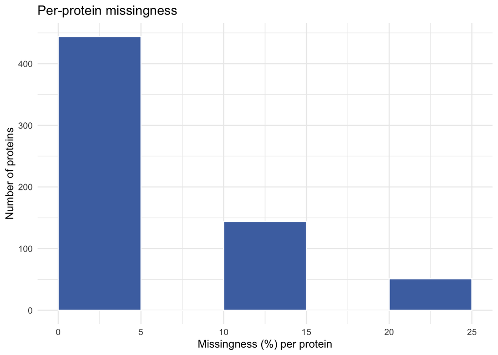

## Volcano plot

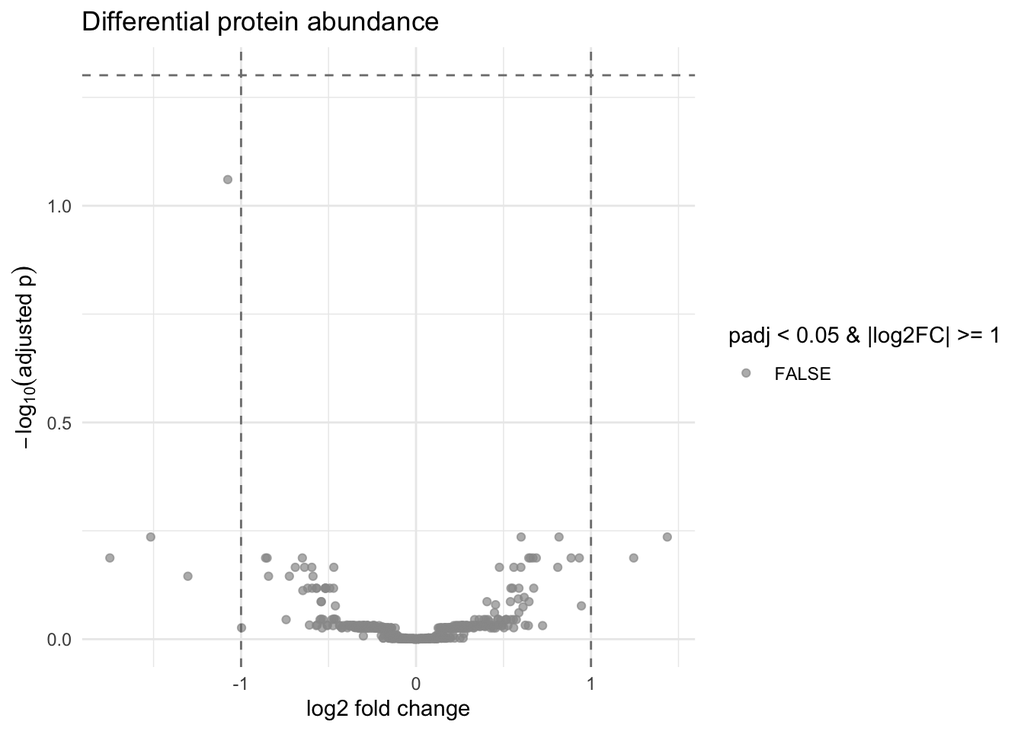

## Top differentially abundant proteins

| protein_accession | gene_symbol | log2FC | lfcSE | pvalue | padj | missingness_percent | analysis_method |
| --- | --- | --- | --- | --- | --- | --- | --- |
| CGI_10023513 | CGI_10023513 | -1.0758365 | 0.1899391 | 0.0001362 | 0.0870190 | 0.0 | spectral_count_limma_moderated_t |
| CGI_10002917 | LOC105333281 | -1.5163193 | 0.3867312 | 0.0027564 | 0.5811465 | 12.5 | spectral_count_limma_moderated_t |
| CGI_10005784 | LOC105332665 | 0.6006569 | 0.1699040 | 0.0045473 | 0.5811465 | 0.0 | spectral_count_limma_moderated_t |
| CGI_10007733 | CGI_10007733 | 0.8172484 | 0.2166886 | 0.0035274 | 0.5811465 | 12.5 | spectral_count_limma_moderated_t |
| CGI_10026867 | LOC105334905 | 1.4361839 | 0.3958512 | 0.0038583 | 0.5811465 | 0.0 | spectral_count_limma_moderated_t |
| CGI_10002226 | LOC105339979 | 1.2442343 | 0.4047953 | 0.0115079 | 0.6495661 | 12.5 | spectral_count_limma_moderated_t |
| CGI_10004563 | LOC105329338 | 0.6445014 | 0.2222694 | 0.0155402 | 0.6495661 | 12.5 | spectral_count_limma_moderated_t |
| CGI_10005339 | LOC105327229 | 0.6684691 | 0.2165278 | 0.0101359 | 0.6495661 | 0.0 | spectral_count_limma_moderated_t |
| CGI_10008722 | CGI_10008722 | 0.8866531 | 0.3068814 | 0.0144811 | 0.6495661 | 0.0 | spectral_count_limma_moderated_t |
| CGI_10011897 | LOC105324811 | -0.8596980 | 0.2879951 | 0.0149611 | 0.6495661 | 25.0 | spectral_count_limma_moderated_t |
| CGI_10013419 | LOC105342224 | 0.6538650 | 0.2215641 | 0.0129520 | 0.6495661 | 0.0 | spectral_count_limma_moderated_t |
| CGI_10016304 | CGI_10016304 | 0.6873566 | 0.2230577 | 0.0113547 | 0.6495661 | 12.5 | spectral_count_limma_moderated_t |
| CGI_10021822 | LOC105340735 | -0.6497151 | 0.2036178 | 0.0084126 | 0.6495661 | 0.0 | spectral_count_limma_moderated_t |
| CGI_10023113 | LOC105330622 | 0.9331854 | 0.3119539 | 0.0132621 | 0.6495661 | 12.5 | spectral_count_limma_moderated_t |
| CGI_10025667 | LOC105328653 | -0.8510577 | 0.3012786 | 0.0162646 | 0.6495661 | 0.0 | spectral_count_limma_moderated_t |
| CGI_10026868 | LOC105334906 | -1.7497706 | 0.5601640 | 0.0105606 | 0.6495661 | 12.5 | spectral_count_limma_moderated_t |
| CGI_10002881 | LOC105347561 | -0.6900350 | 0.2632020 | 0.0251398 | 0.6826493 | 12.5 | spectral_count_limma_moderated_t |
| CGI_10003633 | LOC105344505 | -0.5956030 | 0.2202908 | 0.0218125 | 0.6826493 | 12.5 | spectral_count_limma_moderated_t |
| CGI_10013567 | LOC105332252 | 0.8102290 | 0.3015323 | 0.0208466 | 0.6826493 | 0.0 | spectral_count_limma_moderated_t |
| CGI_10016201 | CGI_10016201 | -0.6372416 | 0.2304118 | 0.0195941 | 0.6826493 | 12.5 | spectral_count_limma_moderated_t |

## Reproducibility

```
List of 16
 $ workflow_name                 : chr "aree/workflows/proteomics"
 $ workflow_version              : chr "0.1.0-scaffold"
 $ mode                          : chr "raw_reanalysis"
 $ study_id                      : chr "TIMMINS2014_OA_GILL"
 $ comparison_id                 : chr "mech_stress_vs_none_at_2800"
 $ date_generated                : chr "2026-10-17T12:04:18.203267-07:00"
 $ generated_by                  : chr "automated:aree-proteomics-workflow@0.1.0-scaffold"
 $ provenance_level              : chr "infra-level (see docs/design.md section 4; distinct from per-row evidence-level provenance)"
 $ inputs                        :List of 2
 $ parameters                    :List of 2
 $ software_versions             :List of 7
 $ software_versions_not_captured:List of 1
 $ container_engine              : NULL
 $ qc_metrics                    :List of 3
 $ missingness_summary           :List of 7
 $ warnings                      : list()
```

This report was generated from TIMMINS2014_OA_GILL_mech_stress_vs_none_at_2800_protein_abundance_standardized.tsv and TIMMINS2014_OA_GILL_mech_stress_vs_none_at_2800_manifest.json by the AREE proteomics workflow scaffold. It is intended to accompany, not replace, the standardized TSV as the machine-readable artifact consumed by `aree harmonize`.